# 11.4 PCA and the Autoencoder

code

share

► [Chapter 11: Linear unsupervised learning](https://jermwatt.github.io/mlrefined/index.html)  
11.4 PCA and the Autoencoder

In this Section we briefly discuss the linear *autoencoder*, which is an important alternative perspective on Principal Component Analysis (PCA). This form of PCA is especially useful because it is more easily extends linear PCA to nonlinear unsupervised learning / PCA - that is finding lower dimensional curves or *manifolds* that best represent a dataset - which will see in the Chapter following this one.

## 11.4.1 The autoencoder cost function for PCA

In Section 12.2.2 we derived the standard PCA solution, consisting of a recovered perpendicular (or orthogonal) set of *principal component* basis vectors based on the eigendecomposition of a data covariance matrix. There we saw how - *under the assumption that the recovered basis $\mathbf{C}$ is orthogonal* i.e., that $\mathbf{C}^T\mathbf{C}^{\,} = \mathbf{I}_{N\times N}$ - that the original PCA Least Squares cost function

\begin{equation} g\left(\mathbf{w}_1,...,\mathbf{w}_P,\mathbf{C}\right) = \frac{1}{P}\sum_{p = 1}^P \left \Vert \mathbf{C}\mathbf{w}_p - \mathbf{x}_p \right\Vert_2^2 \end{equation}

easily reduces to the following Least Squares cost

\begin{equation} g\left(\mathbf{C}\right) = \frac{1}{P}\sum_{p = 1}^P \left \Vert \mathbf{C}_{\,}^{\,}\mathbf{C}_{\,}^T\mathbf{x}_p - \mathbf{x}_p \right\Vert_2^2. \end{equation}

since under this assumption each set of weights can be expressed as $\mathbf{w}_p = \mathbf{C}^T \mathbf{x}_p$.

Indeed it was via further analysis of this form of the PCA cost function that led us to recover the standard orthogonal solution (see Section 12.2.2 for complete description). This form of the PCA cost function is often called the *autoencoder* or *autoencoder cost function* for reasons we will discuss in the example below. Notice that while we did not aim at minimizing this cost function via any local method (like e.g., gradient descent) previously, nothing prohibits us from doing this.

#### Example 1: Learning a partial PCA basis via the autoencoder

We can very quickly translate the autoencoder in equation (2) into `Python` using the same sort of modular philosophy we have employed in previous Chapters. So here we implement the autoencoder cost in two steps. First we construct a `model` function that implements the computation $\mathbf{C}_{\,}^{\,}\mathbf{C}_{\,}^T\mathbf{x}_p$ over all the datapoints. This computation itself is broken into the following two *linear* steps. First the linear *encoding step*.

- **the *encoding* step:** the computation of $\mathbf{w}_p = \mathbf{C}_{\,}^T\mathbf{x}_p$.

The weight vector $\mathbf{w}_p$ 'encodes' the point $\mathbf{x}_p$ as its feature representation (or feature vector) in the space whose coordinate axes are defined by each basis vector of $\mathbf{C}$ (this idea was discussed in significant detail in Sections 11.1 and 11.2). Once encoded, we then linearly *decode* the feature vector.

- **the *decoding* step:** the computation $\mathbf{C}_{\,}^{\,}\mathbf{w}_p$

The representation of $\mathbf{x}_p$ in the original space of the data with with respect to the basis $\mathbf{C}$. When $K < N$, i.e., the number of basis elements is fewer than the dimension of $\mathbf{x}$, is a projection onto the subspace spanned by the elements of $\mathbf{C}$. In other words, in decoding we bring the feature vector $\mathbf{w}_p$ back to the original space in which we started.

Below we implement both the encoding / decoding schemes in two short `Python` functions.

```python
# define our linear encoder
def encoder(c,x):
    return np.dot(c.T,x)

# define our linear decoder
def decoder(c,w):
    return np.dot(c,w)
```

Below in our `model` we perform the full calculation in this encoding-decoding sequence.

```python
# a quick mockup of the autoencoder model
def model(x,c):
    # perform encoding
    w = encoder(c,x)

    # perform decoding
    a = decoder(c,w)
    return a
```

Next we have our autoencoder cost function - a simple Least Squares cost that takes in this model, and whose input/output pairs are precisely the data points $\mathbf{x}_p$.

```python
# an implementation of the least squares cost function for linear regression
def autoencoder(c):
    cost = np.sum((model(x,c) - x)**2)
    return cost/float(x.shape[1])
```

Now we use our standard gradient descent optimizer to tune the parameters of the autoencoder for an $N = 2$ dimensional dataset, which has already been centered. Here we will seek out only a single learned basis vector, and examine its final encoded and decoded versions visually.

```python
# load in a dataset to learn a PCA basis for via the autoencoder
x = np.loadtxt(datapath + '2d_span_data_centered.csv',delimiter=',')

# tune the autoencoder via gradient descent
g = autoencoder; alpha_choice = 10**(-4); max_its = 1000; c = 0.1*np.random.randn(2,1);
weight_history_1,cost_history_1 = optimizers.gradient_descent(g,alpha_choice,max_its,c)
```

Below we plot a number of pictures resulting from minimizing the autoencoder. In the top row the original data is shown in the top left panel along with the single basis vector / principal component found, the encoded data in the middle panel, and the decoded data in the right panel. In the bottom row we show the linear subspace (the span of the single basis vector $\mathbf{c}$ found) in the left panel, and show a vector field plot illustrating how points in the space are projected down onto this subspace.

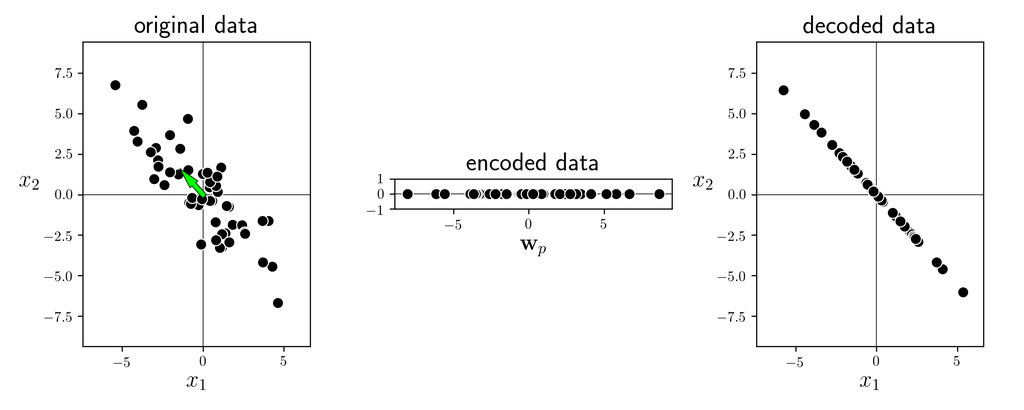

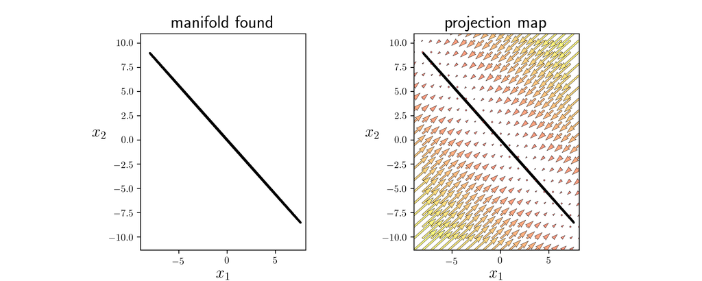

```python
# display results of the autoencoder
unlib.autoencoder_demos.show_encode_decode(x,encoder,decoder,cost_history_1,weight_history_1,show_pc = True,scale = 150,encode_label = r'$\mathbf{w}_p$')
```

Interestingly, examining the contour plot of the autoencoder in this instance we can see that it has two global minima - located precisely at the location of the principal component found (and its negation).

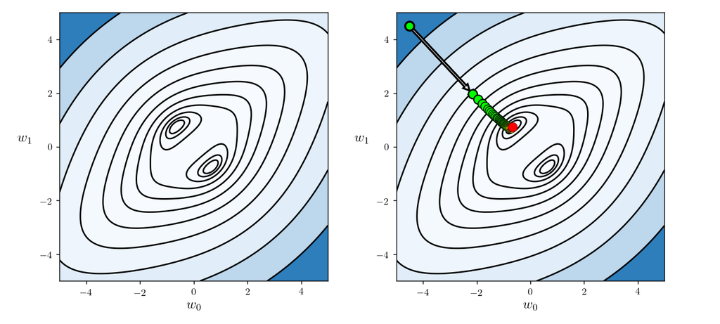

```python
# show run on contour plot
static_plotter.two_input_contour_plot(PCA_least_squares,weight_history_1,xmin = -5,xmax = 5,ymin = -5,ymax = 5,num_contours = 11,show_original = True)
```

## 11.4.2 What value does the autoencoder provide?

Beyond allowing us to easily uncover this special solution, the variation on the PCA cost above has several additional benefits upon closer inspection. First of all it clearly has far fewer parameters to tune than its predecessor - i.e., the weight vectors $\mathbf{w}_p$ need no longer be solved for in the optimization, but come 'for free' on tuning the parameters of $\mathbf{C}$ as $\mathbf{w}_p = \mathbf{C}^T\mathbf{x}_p$.

Even more important is the fact that the cost in equation (2) phrases the PCA problem as a *regression* - where the $p^{th}$ data point we aim at learning a correspondence on consists of the input/output pair $\left(\mathbf{x}_p,\,\mathbf{x}_p\right)$. In other words, the autoencoder in equation (2) phrases the PCA problem as a regression of each point $\mathbf{x}_p$ against itself.

> The linear autoencoder in equation (2) phrases the PCA problem as a regression of each point $\mathbf{x}_p$ against itself

This can perhaps be better appreciated by unwrapping the $p^{th}$ summand of this cost - which is $\left \Vert \mathbf{C}_{\,}^{\,}\mathbf{C}_{\,}^T\mathbf{x}_p - \mathbf{x}_p \right\Vert_2^2$ - and thinking about how the fact that making this value small (upon minimization) forces the approximation below to hold

\begin{equation} \mathbf{C}_{\,}^{\,}\mathbf{C}_{\,}^T\mathbf{x}_p \approx \mathbf{x}_p \end{equation}

\begin{equation} \mathbf{C}_{\,}^{\,}\mathbf{C}_{\,}^T \approx \mathbf{I}_{N\times N} \end{equation}

since this makes all of the approximations above *equalities* and results in an autoencoder cost value of $g\left(\mathbf{C}\right) = 0$. Indeed when we use $K=N$ basis elements a proper minimum of the autoencoder will always produce equality above, i.e., we will always learn the identity $\mathbf{C}_{\,}^{\,}\mathbf{C}_{\,}^T = \mathbf{I}_{N\times N}$. In other words, using the encoding / decoding language introduced in Example 1 above, with the linear autoencoder we seek out a linear encoder / decoder pair that are *functional inverses* of one another.

> With the linear autoencoder we seek out a linear encoder / decoder pair that are *functional inverses* of one another.

#### Example 2. Full basis recovery via the autoencoder

Below we minimize the autoencoder using $K = N = 2$ basis elements using three different random initializations. Indeed we always learn an orthogonal basis for the dataset, but it differs in each case.

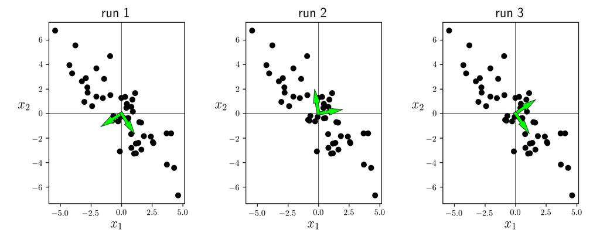

```python
# make three runs of gradient descent to minimie the autoencoder, and plot the resulting
# principal components found
best_weights = []
num_runs = 3
for i in range(num_runs):
    # tune pca least squares cost
    g = autoencoder; alpha_choice = 10**(-2); max_its = 1000; c = 0.1*np.random.randn(2,2);
    weight_history_1,cost_history_1 = optimizers.gradient_descent(g,alpha_choice,max_its,c)

    # pluck out best weights
    ind = np.argmin(cost_history_1)
    w_best = weight_history_1[ind]
    best_weights.append(w_best)

# plot all three autoencoder solutions
unlib.autoencoder_demos.visual_comparison(x,best_weights)
```